# Introduction à la programmation

Roch Delannay

11/8/23

## 1. Les lignes de commande

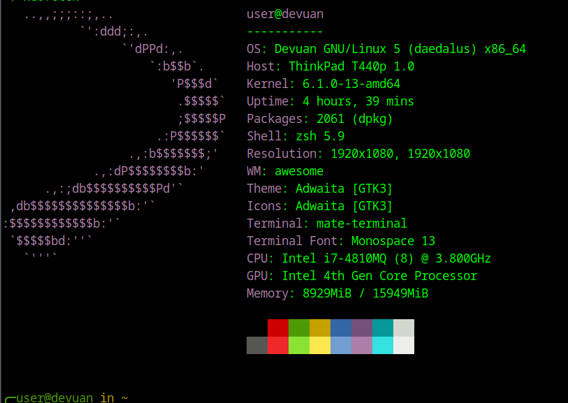

Capture d’écran d’un terminal

### 1.1 Pourquoi utiliser le terminal ?

- Exécuter des scripts Python ;
- Installer des logiciels et des paquets Python ;
- Travailler sur différents ordinateurs depuis votre client ;
- Exécuter des tâches simples (renommer des fichiers en masse, générer des sauvegardes automatiques, convertir des documents, etc.) ;
- Faire de l’analyse de texte basique.

### 1.2 Où trouver l’interface de lignes de commande ?

Votre interface de ligne de commande dépend de votre système d’exploitation. La plupart des OS appartiennent à l’une des deux familles d’OS :

- Unix (MacOS, Linux)
- Windows

Pour les Mac : chercher l’application “Terminal” (Applications -> Utilities).  
Pour Windows : chercher “Powershell”  
Pour Linux : appuyer sur le raccourci clavier ctrl+alt+t

### 1.3 Les commandes les plus courantes

- Pour plus d’informations, voir la section du site dédiée au terminal

## 2. Les fondamentaux de la programmation

```python
# Ceci est une variable
a = 10

# Ceci est une fonction
def polynome(x):
    return 2*x**2 + 4*x + 10

# Ceci est une boucle
for i in range(10) :
    result = polynome(i)
    print(result)
```

### 2.1 Les types de données en programmation

- Strings (chaînes de caractères)
- Integers (nombres entiers)
- Floats (nombres décimaux)
- Booleans (true/false)

`6` n’est pas la même chose que `"6"`.

### 2.2 Les variables

Les variables sont des boîtes dans lesquelles on stocke des objets tels que des données, des noms de fichier, etc.

```python
a = 10

b = "Stylo"
```

### 2.3 Les boucles

Une boucle permet de répéter une même action selon une certaine condition.

```python
# Ceci est une boucle
for i in range(10) :
    print(i**2)
```

### 2.4 Les ensembles de données

- liste
- dictionnaire
- pile
- file

Exemple d’une liste :

```python
liste_de_fruits = ["Pomme", "Banane", "Poire", "Orange"]
```

### 2.5 Les tests if/else

> Si demain il neige, alors je porterais une parka, si non, je porterais un t-shirt.

> Si l’utilisateur est âgé de plus de 18 ans, il peut conduire la voiture, si non, il devra prendre les transports en commun.

```python
note_etudiant1 = 90

if note_etudiant1 >= 70 :
    print("Félicitations !")
```

### 2.6 Les fonctions

Une fonction désigne en programmation un « sous-programme » permettant d’effectuer des opérations répétitives ([Wikipédia](https://fr.wikiversity.org/wiki/Introduction_g%C3%A9n%C3%A9rale_%C3%A0_la_programmation/Fonctions)).

```python
# Ceci est une fonction
def polynome(x):
    return 2*x**2 + 4*x + 10
```

## 3. Démonstration

Voir le script tutoriel.py et le texte de Dracula.

HNU2000 - Université de Montréal - Aut. 2023